# EEMB146 Lab 8 Exercise

## Exercise 2: Model Selection

In lecture, we discussed how to calculate Aikake’s Information Criterion (AIC) from the log-likelihood of a model. Remember that AIC is only a valid comparison between models that were fitted using exactly the same data. The absolute value of the AIC doesn’t matter; we are only concerned about the *relative* value of AIC. A model with a smaller AIC value performs relatively better than a model with a larger AIC value. Don’t get tripped up by negative AICs - **we are looking for overall smallest, not closest to 0**.

We can also compare models using the BIC. AIC and BIC should generally lead us to similar results, but BIC places a higher penalty on extra parameters. This helps to enforce the principle of parsimony - that a simpler model is best.

Finally, we can compare the adjusted R-squared value for each model to see how much variation in the y-variable is explained by each combination of predictors. We are looking for a model with high adjusted R-squared.

It is often convenient to print all of these values for each model as a neat table, so that your reader can compare them all at a glance. The function kable() in the package knitr allows us to print a dataframe as a table in html, pdf, or latex format (run in console, not in your markdown, to see the different formats). Look up the help documentation for kable using ?kable. You can specify left, right, or center alignment, give the number of digits to round to for the whole table or for each column individually, edit the names of your columns, and more to get the perfect beautiful table for your report.

```r
## Step 5. Calculate AIC of each model
# because we used slightly different date for fit_mixed (ie removed all of the NAs), we can't compare that model with the fixed effect models (fit_1var...fit_3var). We encourage you to create more mixed-effect models and compare those if you are interested in building the best possible model.
results <- AIC(fit_1var,fit_2var,fit_3var)


## Step 6. Add other metrics to the results table
models <- list(fit_1var,fit_2var,fit_3var) # make sure you keep your models in the same order here as they were when you created them in 'results_AIC'

results$BIC <- sapply(models, BIC) # add a column for BIC to the results

model_summary <- lapply(models, summary) #look up ?lapply if you have not used this function before


## Step 7. Extract relevant information from model summaries
# we will use a for loop to easily extract the R^2 and adj R^2 value for each model from its summary, and store them in new columns in the results table

for(i in 1:length(models)){ #this creates a variable i that starts with the value i=1
  results$rsq[i] <- model_summary[[i]]$r.squared #we assign the rsq value from model i to the i'th row of the column 'rsq' in the table 'results'
  results$adj_rsq[i] <- model_summary[[i]]$adj.r.squared #same for adjusted rsq
} #now we go back to the beginning of the for-loop, add 1 to the value of i, and do everything again


## Step 8. Create a nice kable with model results
# there are so so many ways to make kable tables look nicer, highly recommend checking out additional commands here: https://bookdown.org/yihui/rmarkdown-cookbook/kable.html#change-column-names
kable(results, # data you want visualized
      digits = 2, # sigfigs
      align = "c") # change alignment
```

|  | df | AIC | BIC | rsq | adj_rsq |
| --- | --- | --- | --- | --- | --- |
| fit_1var | 3 | 1083.71 | 1091.84 | 0.12 | 0.11 |
| fit_2var | 4 | 1033.82 | 1044.65 | 0.45 | 0.44 |
| fit_3var | 5 | 998.72 | 1012.26 | 0.61 | 0.59 |

```r
## Step 9. Decide which model is the best (see below)
```

Deciding what is the “best fit” model is an important step of modeling and will require the consideration of many things such as; what model has lowest AIC? what model has highest $R^2$? what model balances the trade off between complexity and explaining enough variance? what model make actual biological sense? this sort of questioning happens every day when people are “modeling”. However, we don’t expect you to be experts here! For your homework go off of the AIC/BIC/$R^2$, but for your final project we will require you to bring some biological intuition of what model makes the most sense while adhering to the rules of parsimony. Based on the mentioned criteria, model ‘fit_3var’ is the best model due to the lowest AIC and highest $R^2$.

## Exercise 3: Assess Model Fit

When you have chosen your best model based on AIC, BIC, adjusted $R^2$, and the principle of parsimony, you will want to check how well it fits the data. Are the residuals normally distributed? How large are the residuals? If you leave some datapoints out when you fit the model, can you use your model to predict those points accurately?

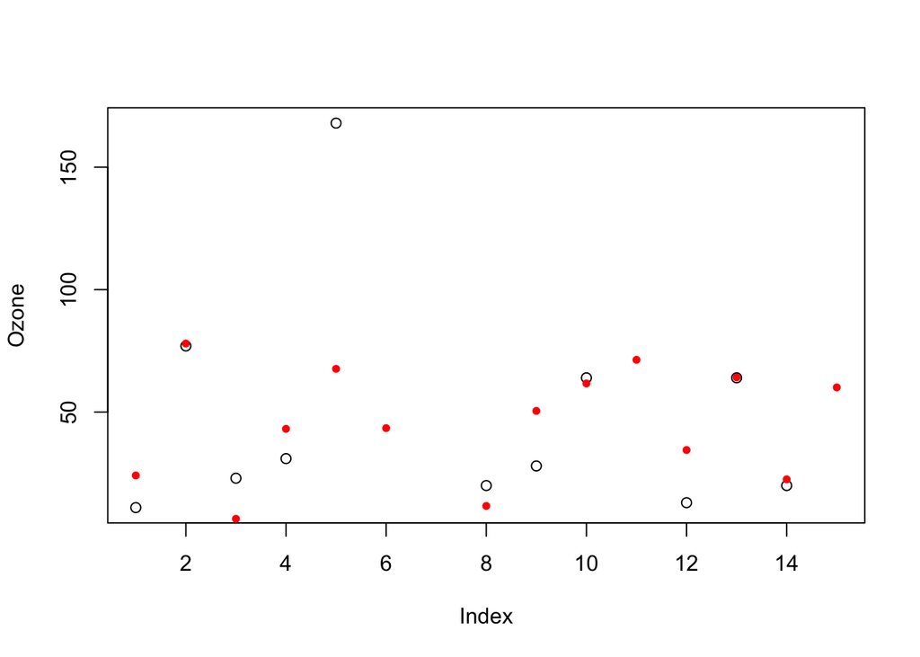

```r
## Step 9. Separate data into a training and testing sets
# You will separate your data into a training set (most of the data) and a test set (a few observations, or <10% of rows)

splitter <- sample(1:nrow(airquality), 15, replace = F) # pick 15 random rows from air_quality, don't replace
airqual_train <- airquality[-splitter,] # leave those rows out of training data
airqual_test <- airquality[splitter,] # use those rows to create a set of test data


## Step 10. Use the best fit model on TRAINING set
fit_3var_train <- lm(ozone ~ solar_r + wind + temp,
               data = airqual_train)

## Step 11. Use the fitted model with training data to make predictions of your Y outcome
fit_3var_train_predict <- predict(fit_3var_train,
                                  airqual_test)


## Step 12. Visualize how your best fit model did with predictions
plot(airqual_test$ozone, pch = 1, ylab = "Ozone") # plot actual test data values
points(fit_3var_train_predict, pch = 20, col = "red") # plot the model predictions for those points
```

At a first glance, we can see that we don’t have a lot of overlap of red and open circles. If we built a perfect model, we would have complete overlap of red/open circles at each index. For a very simple exercise like this, this makes sense our model didn’t predict perfectly. Ozone is a very complicated biogeochemical process that is difficult to encapsulated in < 200 data points and 3 variables. Hopefully this exercise can be a framework for your final project model where you bring your biological intuition to a higher quality data set!

# Additional Resources for Final Project

For your Final Project, you will be responsible for creating a professional looking report about a biological system you investigated using statistical tests and R skills you learned throughout EEMB 146. Some additional resources that will be helpful are :

- [build prettier kable tables](https://bookdown.org/yihui/rmarkdown-cookbook/kable.html#change-column-names)
- [another way to visualize regression summaries](https://jtools.jacob-long.com/reference/summ.html)

# Vocab

For those who would like more visual examples of how to interpret linear model outputs and diagnostic plots, these resources will be helpful!

- [more practice w/ interpretting lm outputs](https://feliperego.github.io/blog/2015/10/23/Interpreting-Model-Output-In-R)
- [more practice w/ interpretting diagnostic plots for lm](https://data.library.virginia.edu/diagnostic-plots/)

## Appendix: using stepwise model selection (optional)

Model selection is a very complex problem for statisticians, and we have just scratched the surface here. There are many other ways to choose appropriate combinations of predictor variables. One example is stepwise model selection. This process starts with a ‘full model’ (including all possible predictors) and eliminates variables one by one, calculating AIC each time. When the AIC can’t be reduced any more by taking away variables or putting them back, you have the final optimized model. You can try stepwise AIC in R:

```r
# install.packages("MASS") new package for stepAIC
library(MASS)

fullmodel <- lm(ozone~solar_r+wind+temp+month+day, data = airquality)
nullmodel <- lm(ozone~1, data = airquality)

stepAIC(fullmodel, scope = c(upper = fullmodel, lower = nullmodel), direction = "both")
```

```
## Start:  AIC=680.21
## ozone ~ solar_r + wind + temp + month + day
##
##           Df Sum of Sq   RSS    AIC
## - day      1     618.7 46302 679.71
## <none>                 45683 680.21
## - month    1    1755.3 47438 682.40
## - solar_r  1    2005.1 47688 682.98
## - wind     1   11533.9 57217 703.20
## - temp     1   20845.0 66528 719.94
##
## Step:  AIC=679.71
## ozone ~ solar_r + wind + temp + month
##
##           Df Sum of Sq   RSS    AIC
## <none>                 46302 679.71
## - month    1    1701.2 48003 681.71
## - solar_r  1    1952.6 48254 682.29
## - wind     1   11520.5 57822 702.37
## - temp     1   20419.5 66721 718.26
```

```
##
## Call:
## lm(formula = ozone ~ solar_r + wind + temp + month, data = airquality)
##
## Coefficients:
## (Intercept)      solar_r         wind         temp        month
##    -58.0538       0.0496      -3.3165       1.8709      -2.9916
```

How does including interactions affect this process? Do you get similar results from the automated selection as you did in the homework by using your biological intuition and comparing models by hand?

### Appendix: ozone in the news

https://www.npr.org/sections/health-shots/2020/05/19/854760999/traffic-is-way-down-due-to-lockdowns-but-air-pollution-not-so-much

### End of Exercise 8